# Effects of natural events in health and economics

Ricardo Leon

January 17, 2020

## Synopsis

Every year natural disasters produce a wide variaty of loses. Two of them are the subject to study in this report, injuries and fatalities and properties and crops damages. Using R libraries to process data (dplyr) and plot results (ggplot2) will help us to find out the most harmful event and the one with the greatest economics consequences. At the end, we get that tornados causes the most injuries and fatalities of all events and floods causes the greatest economics consequences.

## Data Processing

The first step is to load the required libraries.

- dplyr for data proccessing.
- ggplot2 and RColorBrewer for plotting results.

```r
library(dplyr)
library(tidyr)
library(ggplot2)
library(RColorBrewer)
```

Given the download url, we get the data from the cloud, then unzip it and finally load it into R.

```r
url <- "https://d396qusza40orc.cloudfront.net/repdata%2Fdata%2FStormData.csv.bz2"
file_name <- "repdata_data_StormData.csv.bz2"

if (!file.exists(file_name)) {
    download.file(url, destfile = "repdata_data_StormData.csv.bz2")
}

data <- read.csv("repdata_data_StormData.csv.bz2", header = TRUE, sep = ",", stringsAsFactors = FALSE)
```

Looking at the data, it can be noticed that EVTYPE column values have many typos and synonyms for the same natural event. Using regular expressions and dplyr library, we will fix this issue. The procedure is as follows:

- Remove rows with EVTYPE ‘?’ and contains ‘SUMMARY’ as the first word.
- Transform all letter to upper case.
- Apply regular expression on the values belonging to the same group (it can be checked below).

```r
data <- data %>%
    filter(EVTYPE != "?", !grepl("^SUMMARY", EVTYPE)) %>%
    mutate(EVTYPE = toupper(EVTYPE),
           EVTYPE = replace(EVTYPE, grepl("WIND|WND|TURBULENCE", EVTYPE), "HIGH WINDS"),
           EVTYPE = replace(EVTYPE, grepl("FLO{0,3}D|URBAN", EVTYPE), "FLOODS"),
           EVTYPE = replace(EVTYPE, grepl("AVAL", EVTYPE), "AVALANCHES"),
           EVTYPE = replace(EVTYPE, grepl("LIG(HTI|HTN|NTN)", EVTYPE), "LIGHTNINGS"),
           EVTYPE = replace(EVTYPE, grepl("COLD|CHILL|LOW TEMP|COOL|FROST|HYPOTHERMIA|FREEZE", EVTYPE), "COLD TEMPERATURES"),
           EVTYPE = replace(EVTYPE, grepl("HIGH TEMP|HOT|HYPERTHERMIA|HEAT", EVTYPE), "HIGH TEMPERATURES"),
           EVTYPE = replace(EVTYPE, grepl("HIGH (SURF|SEAS|TIDE|WATER|WAVES)|SURF|SWELLS", EVTYPE), "HIGH TIDES"),
           EVTYPE = replace(EVTYPE, grepl("BLOW-OUT TIDE|SURGE|SEAS", EVTYPE), "HIGH TIDES"),
           EVTYPE = replace(EVTYPE, grepl("SNOW|BLIZ|WINT|ICE( STORM)?|FREEZ.*(RAIN|SPRAY|FOG|DRIZZLE)|SLEET", EVTYPE), "BLIZZARDS"),
           EVTYPE = replace(EVTYPE, grepl("TSTM( WND|W)?|THU", EVTYPE), "THUNDERSTORMS"),
           EVTYPE = replace(EVTYPE, grepl("WILD", EVTYPE), "FOREST FIRES"),
           EVTYPE = replace(EVTYPE, grepl("DUST", EVTYPE), "DUST STORMS"),
           EVTYPE = replace(EVTYPE, grepl("RAIN|SHOWER|PRECIP", EVTYPE), "RAIN"),
           EVTYPE = replace(EVTYPE, grepl("WAY?TER.*(SPOUT)?", EVTYPE), "WATERSPOUTS"),
           EVTYPE = replace(EVTYPE, grepl("VOL", EVTYPE), "VOLCANIC ERUPTION"),
           EVTYPE = replace(EVTYPE, grepl("LANDSPOUT|TORN", EVTYPE), "TORNADOS"),
           EVTYPE = replace(EVTYPE, grepl("HAIL.*(STORM)?", EVTYPE), "HAIL STORMS"),
           EVTYPE = replace(EVTYPE, grepl("COAST.*STORM", EVTYPE), "COASTAL STORMS"),
           EVTYPE = replace(EVTYPE, grepl("TROPICAL", EVTYPE), "TROPICAL STORMS"),
           EVTYPE = replace(EVTYPE, grepl("WET", EVTYPE), "WET WEATHER"),
           EVTYPE = replace(EVTYPE, grepl("WARM", EVTYPE), "WARM WEATHER"),
           EVTYPE = replace(EVTYPE, grepl("SLIDE", EVTYPE), "LANDSLIDE"),
           EVTYPE = replace(EVTYPE, grepl("HURRICANE|TYPHOON", EVTYPE), "HURRICANE/TYPHOON"),
           EVTYPE = replace(EVTYPE, grepl("CLOUD", EVTYPE), "CLOUDS"),
           EVTYPE = replace(EVTYPE, grepl("RIP", EVTYPE), "RIP CURRENTS"),
           EVTYPE = replace(EVTYPE, grepl("EROSI", EVTYPE), "COASTAL EROSION"),
           EVTYPE = replace(EVTYPE, grepl("FIRE", EVTYPE), "FIRES"),
           EVTYPE = replace(EVTYPE, grepl("FOG", EVTYPE), "FOG"),
           EVTYPE = replace(EVTYPE, grepl("DAM (BREAK|FAILURE)", EVTYPE), "DAM FAILURES"),
           EVTYPE = replace(EVTYPE, grepl("SMOKE", EVTYPE), "SMOKE"),
           EVTYPE = replace(EVTYPE, grepl("DR(Y|IEST|OUGHT)", EVTYPE), "DROUGHT"))
```

To get a ranking of types of events with most harmful effects on population health we will consider only three columns (EVTYPE, INJURIES, FATALITIES). We will apply the following steps on the data:

- Group by event type.
- Summarise the total number for injuries, fatalities and both of them, all by event type.
- Arrange data in descending order by total number of affected people.
- Take the 5 most harmful events.
- Merge all 3 information columns to create 2 (DMGTYPE & QTY). This will help us to plot it easily.

```r
most_harmful_events <- data %>%
                            group_by(EVTYPE) %>%
                            summarise(INJURIES = sum(INJURIES), FATALITIES = sum(FATALITIES)) %>%
                            mutate(TOTAL = INJURIES + FATALITIES) %>%
                            arrange(desc(TOTAL)) %>%
                            top_n(5) %>%
                            gather(key=DMGTYPE, value=QTY, -EVTYPE)
```

In order to get the data required to measure the event with the greatest economics consequences, we apply the following steps:

- Select columns EVTYPE, PROPDMG, PROPDMGEXP, CROPDMG and CROPDMGEXP.
- To work with values in billions, we substitute in columns PROPDMGEXP and CROPDMGEXP the letters ‘k’, ‘m’ and ‘b’ with the corresponding numerical factor values. Assign zero otherwise (check Appendix A for explanations).
- Convert recent transformed columns into numeric.
- Create 2 new columns TOTAL_PROP & TOTAL_CROP to contain amounts for PROPDMG and CROPDMG in billions.
- Keep EVTYPE, TOTAL_PROP and TOTAL_CROP columns.
- Group data by event type.
- Get totals by event type.
- Create TOTAL column to summarise amount types
- Arrange in descending order of total costs.
- Take the top 5 events with most economics consequences.
- Merge all 3 information columns to create 2 (DMGTYPE & AMOUNT). This will help us to plot it easily.

```r
most_costly_events <- data %>%
            select(EVTYPE, PROPDMG, PROPDMGEXP, CROPDMG, CROPDMGEXP) %>%
            mutate(PROPDMGEXP = replace(PROPDMGEXP, !(tolower(PROPDMGEXP) %in% c("b", "m", "k")), "0"),
                   PROPDMGEXP = replace(PROPDMGEXP, tolower(PROPDMGEXP) == "k", "0.000001"),
                   PROPDMGEXP = replace(PROPDMGEXP, tolower(PROPDMGEXP) == "m", "0.001"),
                   PROPDMGEXP = replace(PROPDMGEXP, tolower(PROPDMGEXP) == "b", "1"),
                   CROPDMGEXP = replace(CROPDMGEXP, !(tolower(CROPDMGEXP) %in% c("b", "m", "k")), "0"),
                   CROPDMGEXP = replace(CROPDMGEXP, tolower(CROPDMGEXP) == "k", "0.000001"),
                   CROPDMGEXP = replace(CROPDMGEXP, tolower(CROPDMGEXP) == "m", "0.001"),
                   CROPDMGEXP = replace(CROPDMGEXP, tolower(CROPDMGEXP) == "b", "1"),
                   PROPDMGEXP = as.numeric(PROPDMGEXP),
                   CROPDMGEXP = as.numeric(CROPDMGEXP),
                   TOTAL_PROP = PROPDMG * PROPDMGEXP,
                   TOTAL_CROP = CROPDMG * CROPDMGEXP) %>%
            select(EVTYPE, TOTAL_PROP, TOTAL_CROP) %>%
            group_by(EVTYPE) %>%
            summarise(PROP = sum(TOTAL_PROP), CROP = sum(TOTAL_CROP)) %>%
            mutate(TOTAL = PROP + CROP) %>%
            arrange(desc(TOTAL)) %>%
            top_n(5) %>%
            gather(key=DMGTYPE, value=AMOUNT, -EVTYPE)
```

## Results

Plotting our results will help us to get insight from the data. For the most harmful to population health events we have:

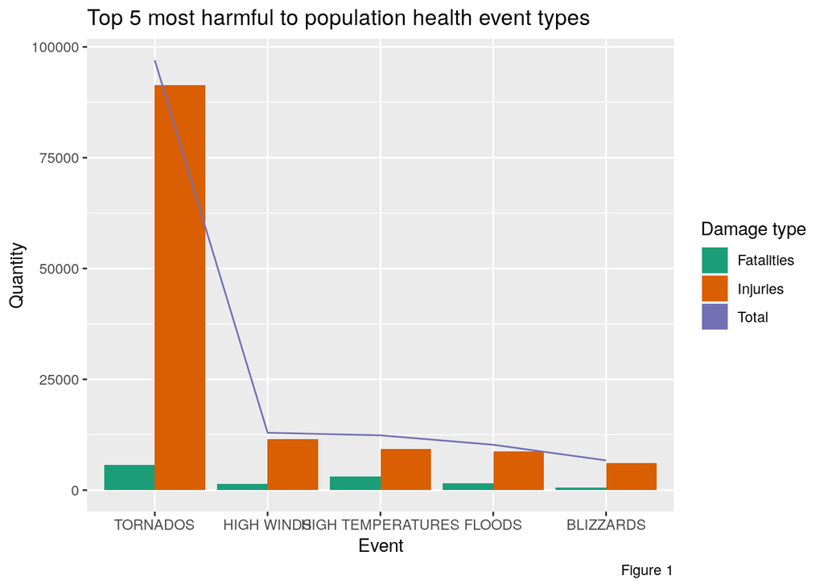

```r
color_pallete <- brewer.pal(3, "Dark2")
line_color <- color_pallete[3]
legend_labels <- c("Fatalities", "Injuries", "Total")
most_harmful_events_without_total <- most_harmful_events %>% filter(DMGTYPE != "TOTAL")
most_harmful_events_totals <- most_harmful_events %>% filter(DMGTYPE == "TOTAL")

ggplot(most_harmful_events_without_total, aes(x=reorder(EVTYPE, -QTY), y=QTY, fill=factor(DMGTYPE))) +
    geom_bar(stat = "identity", position = "dodge") +
    scale_fill_manual(name="Damage type", values=color_pallete, labels=legend_labels) +
    geom_line(data = most_harmful_events_totals, aes(x=EVTYPE, y=QTY, group=1), colour=line_color) +
    xlab("Event") + ylab("Quantity") +
    labs(title = "Top 5 most harmful to population health event types", caption = "Figure 1")
```

From Figure 1, we have the following insights:

- The most harmful events are **tornados**.
- In descending order of harmfulness, high winds, high temperatures, floods and blizzards follows.
- Tornados are significantly more harmful than others events.
- Number of injured people is greater than fatalities.

The same reasoning can be applied for the events with the greatest economics consequences:

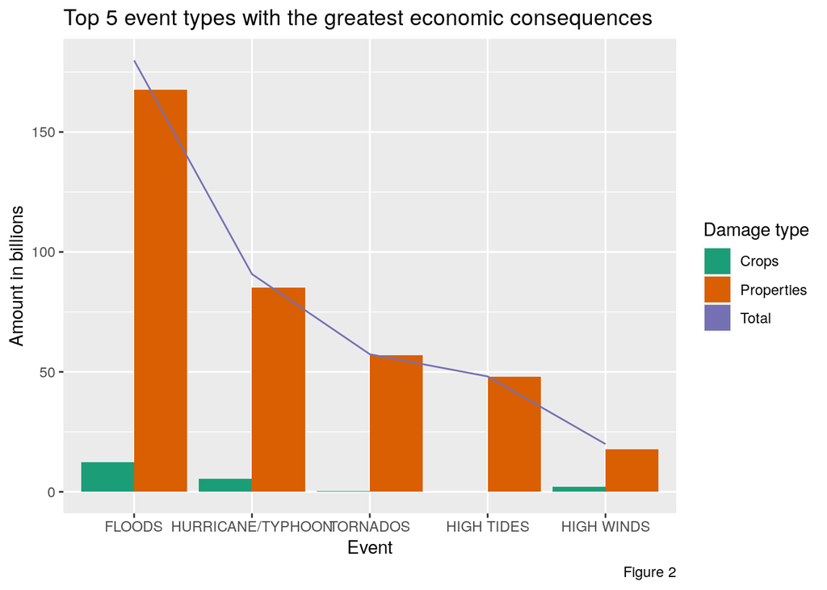

```r
legend_labels <- c("Crops", "Properties", "Total")
most_costly_events_without_total <- most_costly_events %>% filter(DMGTYPE != "TOTAL")
most_costly_events_totals <- most_costly_events %>% filter(DMGTYPE == "TOTAL")

ggplot(most_costly_events_without_total, aes(x=reorder(EVTYPE, -AMOUNT), y=AMOUNT, fill=factor(DMGTYPE))) +
    geom_bar(stat = "identity", position = "dodge") +
    scale_fill_manual(name="Damage type", values=color_pallete, labels=legend_labels) +
    geom_line(data = most_costly_events_totals, aes(x=EVTYPE, y=AMOUNT, group=1), colour=line_color) +
    xlab("Event") + ylab("Amount in billions") +
    labs(title = "Top 5 event types with the greatest economic consequences", caption = "Figure 2")
```

From Figure 2, we have the following insights:

- The events with the greatest economics consequences are **floods**.
- In descending order of consequences, hurricanes/typhoons, tornados, high tides and high winds follows.
- Floods generates almost twice economics loses than hurricanes/typhoons.

## Appendix A

### Why to discard observations with values different from “b”, “m” and “k”

Exploring the data, we can figure out some important insights.

```r
bmk <- data %>% select(EVTYPE, PROPDMG, PROPDMGEXP, CROPDMG, CROPDMGEXP)
table(bmk$PROPDMGEXP)
```

```
##
##             -      ?      +      0      1      2      3      4      5      6
## 465931      1      8      5    216     25     13      4      4     28      4
##      7      8      B      h      H      K      m      M
##      5      1     40      1      6 424664      7  11330
```

```r
table(bmk$PROPDMG[bmk$PROPDMGEXP == ""])
```

```
##
##      0   0.41      1      2      3      4      5      6      7      8      9
## 465855      1      4      7     16      9     11      6      3      2      3
##     10     20     35     75
##      8      4      1      1
```

```r
table(bmk$PROPDMG[tolower(bmk$PROPDMGEXP) == "h"])
```

```
##
## 2 3 5
## 2 1 4
```

```r
table(bmk$CROPDMGEXP)
```

```
##
##             ?      0      2      B      k      K      m      M
## 618409      7     19      1      9     21 281832      1   1994
```

```r
table(bmk$CROPDMG[bmk$CROPDMGEXP == ""])
```

```
##
##      0      3      4
## 618406      1      2
```

**Conclusion**: To avoid noise due to unknown data, we remove from the total calculations numeric values with EXP different from ‘b’, ‘m’ and ‘k’.